```python
import time,datetime
start_time = time.time()
```

```python
import numpy as np
import pandas as pd

import matplotlib.pyplot as plt
import seaborn as sns
import missingno as msno
import dataprep.eda as eda
import qgrid
import plotly.express as px

bleu = (70 / 255, 130 / 255, 180 / 255)
pd.set_option('display.max_row', 50)
pd.set_option('display.max_column', 50)
pd.set_option('display.max_colwidth', 50)
```

```
NumExpr defaulting to 8 threads.
```

# Chargement des données

```python
customers = pd.read_csv('olist_customers_dataset.csv')
geolocation = pd.read_csv('olist_geolocation_dataset.csv')
order_items = pd.read_csv('olist_order_items_dataset.csv')
order_payments = pd.read_csv('olist_order_payments_dataset.csv')
order_reviews = pd.read_csv('olist_order_reviews_dataset.csv')
orders = pd.read_csv('olist_orders_dataset.csv')
products = pd.read_csv('olist_products_dataset.csv')
sellers = pd.read_csv('olist_sellers_dataset.csv')
product_category_name_translation = pd.read_csv(
    'product_category_name_translation.csv')
```

# Relations entre les tables

```python
# Function giving a review of missing values per columns on a dataframe
def missing_values(table, tri=True, sens=True):
    # Total Nan
    mis_val = table.isnull().sum()

    # Nan percent
    mis_val_percent = table.isnull().sum() / len(table) * 100

    # Data Frame to hold results
    mis_val_table = pd.concat([mis_val, mis_val_percent], axis=1)

    # Naming columns
    mis_val_table_ren_columns = mis_val_table.rename(
        columns={0: 'Missing values', 1: '% on total values'})

    if tri:
        # sort Nan percent on sens : bool
        mis_val_table_ren_columns = mis_val_table_ren_columns[
            mis_val_table_ren_columns.iloc[:, 1] != 0].sort_values(
            '% on total values', ascending=sens).round(2)
    else:
        # whitout sort on Nan percent
        mis_val_table_ren_columns = mis_val_table_ren_columns[
            mis_val_table_ren_columns.iloc[:, 1] != 0].sort_values(
            '% on total values', ascending=False).round(2)

    # Summary : dataframe name, number of Nan containing columns
    print(' Dataframe as ' + str(table.shape[1]) + ' columns.\n',
          str(mis_val_table_ren_columns.shape[0]) +
          ' columns containing Nans.')

    # Return dataframe with stats per columns
    return mis_val_table_ren_columns
```

[figure not shown]

```python
# Collections for each dataset
datasets = [customers, geolocation, orders, order_items, order_payments,
            order_reviews, products, sellers]
names = ['olist_customer', 'olist_geolocation', 'olist_orders', 'olist_order_items', 'olist_order_payments',
         'olist_order_reviews', 'olist_products', 'olist_sellers']

# Creating a DataFrame with useful information about all datasets
data_info = pd.DataFrame({})
data_info['dataset'] = names
data_info['n_rows'] = [df.shape[0] for df in datasets]
data_info['n_cols'] = [df.shape[1] for df in datasets]
data_info['null_amount'] = [df.isnull().sum().sum() for df in datasets]
data_info['qty_null_columns'] = [len([col for col, null in df.isnull().sum().items() if null > 0]) for df in datasets]
data_info['null_columns'] = [', '.join([col for col, null in df.isnull().sum().items() if null > 0]) for df in datasets]

data_info.style.background_gradient()
```

|  | dataset | n_rows | n_cols | null_amount | qty_null_columns | null_columns |
| --- | --- | --- | --- | --- | --- | --- |
| 0 | olist_customer | 99441 | 5 | 0 | 0 |  |
| 1 | olist_geolocation | 1000163 | 5 | 0 | 0 |  |
| 2 | olist_orders | 99441 | 8 | 4908 | 3 | order_approved_at, order_delivered_carrier_date, order_delivered_customer_date |
| 3 | olist_order_items | 112650 | 7 | 0 | 0 |  |
| 4 | olist_order_payments | 103886 | 5 | 0 | 0 |  |
| 5 | olist_order_reviews | 100000 | 7 | 146532 | 2 | review_comment_title, review_comment_message |
| 6 | olist_products | 32951 | 9 | 2448 | 8 | product_category_name, product_name_lenght, product_description_lenght, product_photos_qty, product_weight_g, product_length_cm, product_height_cm, product_width_cm |
| 7 | olist_sellers | 3095 | 4 | 0 | 0 |  |

# Merge

Table olist_orders_datase

```python
# overview head and shape
display(orders.sort_values(by='order_id').head(10))
```

|  | order_id | customer_id | order_status | order_purchase_timestamp | order_approved_at | order_delivered_carrier_date | order_delivered_customer_date | order_estimated_delivery_date |
| --- | --- | --- | --- | --- | --- | --- | --- | --- |
| 85267 | 00010242fe8c5a6d1ba2dd792cb16214 | 3ce436f183e68e07877b285a838db11a | delivered | 2017-09-13 08:59:02 | 2017-09-13 09:45:35 | 2017-09-19 18:34:16 | 2017-09-20 23:43:48 | 2017-09-29 00:00:00 |
| 71853 | 00018f77f2f0320c557190d7a144bdd3 | f6dd3ec061db4e3987629fe6b26e5cce | delivered | 2017-04-26 10:53:06 | 2017-04-26 11:05:13 | 2017-05-04 14:35:00 | 2017-05-12 16:04:24 | 2017-05-15 00:00:00 |
| 6298 | 000229ec398224ef6ca0657da4fc703e | 6489ae5e4333f3693df5ad4372dab6d3 | delivered | 2018-01-14 14:33:31 | 2018-01-14 14:48:30 | 2018-01-16 12:36:48 | 2018-01-22 13:19:16 | 2018-02-05 00:00:00 |
| 22550 | 00024acbcdf0a6daa1e931b038114c75 | d4eb9395c8c0431ee92fce09860c5a06 | delivered | 2018-08-08 10:00:35 | 2018-08-08 10:10:18 | 2018-08-10 13:28:00 | 2018-08-14 13:32:39 | 2018-08-20 00:00:00 |
| 5247 | 00042b26cf59d7ce69dfabb4e55b4fd9 | 58dbd0b2d70206bf40e62cd34e84d795 | delivered | 2017-02-04 13:57:51 | 2017-02-04 14:10:13 | 2017-02-16 09:46:09 | 2017-03-01 16:42:31 | 2017-03-17 00:00:00 |
| 69449 | 00048cc3ae777c65dbb7d2a0634bc1ea | 816cbea969fe5b689b39cfc97a506742 | delivered | 2017-05-15 21:42:34 | 2017-05-17 03:55:27 | 2017-05-17 11:05:55 | 2017-05-22 13:44:35 | 2017-06-06 00:00:00 |
| 98566 | 00054e8431b9d7675808bcb819fb4a32 | 32e2e6ab09e778d99bf2e0ecd4898718 | delivered | 2017-12-10 11:53:48 | 2017-12-10 12:10:31 | 2017-12-12 01:07:48 | 2017-12-18 22:03:38 | 2018-01-04 00:00:00 |
| 47316 | 000576fe39319847cbb9d288c5617fa6 | 9ed5e522dd9dd85b4af4a077526d8117 | delivered | 2018-07-04 12:08:27 | 2018-07-05 16:35:48 | 2018-07-05 12:15:00 | 2018-07-09 14:04:07 | 2018-07-25 00:00:00 |
| 92213 | 0005a1a1728c9d785b8e2b08b904576c | 16150771dfd4776261284213b89c304e | delivered | 2018-03-19 18:40:33 | 2018-03-20 18:35:21 | 2018-03-28 00:37:42 | 2018-03-29 18:17:31 | 2018-03-29 00:00:00 |
| 83215 | 0005f50442cb953dcd1d21e1fb923495 | 351d3cb2cee3c7fd0af6616c82df21d3 | delivered | 2018-07-02 13:59:39 | 2018-07-02 14:10:56 | 2018-07-03 14:25:00 | 2018-07-04 17:28:31 | 2018-07-23 00:00:00 |

```python
# Eye on one particular order
orders[orders.order_id == 'e481f51cbdc54678b7cc49136f2d6af7']
```

|  | order_id | customer_id | order_status | order_purchase_timestamp | order_approved_at | order_delivered_carrier_date | order_delivered_customer_date | order_estimated_delivery_date |
| --- | --- | --- | --- | --- | --- | --- | --- | --- |
| 0 | e481f51cbdc54678b7cc49136f2d6af7 | 9ef432eb6251297304e76186b10a928d | delivered | 2017-10-02 10:56:33 | 2017-10-02 11:07:15 | 2017-10-04 19:55:00 | 2017-10-10 21:25:13 | 2017-10-18 00:00:00 |

```python
# Corresponding payment
order_payments[order_payments.order_id == 'e481f51cbdc54678b7cc49136f2d6af7']
```

|  | order_id | payment_sequential | payment_type | payment_installments | payment_value |
| --- | --- | --- | --- | --- | --- |
| 10770 | e481f51cbdc54678b7cc49136f2d6af7 | 1 | credit_card | 1 | 18.12 |
| 44246 | e481f51cbdc54678b7cc49136f2d6af7 | 3 | voucher | 1 | 2.00 |
| 91130 | e481f51cbdc54678b7cc49136f2d6af7 | 2 | voucher | 1 | 18.59 |

Pour une même commande plusieurs payements sont referencés dans la table order_payments. aggrégation sur order_id creation des variables:

```
* payment_sequential: nombre de paments
* payement_installements: payement en X fois
* payment_value: total
```

```python
# groupby
order_payments=order_payments.groupby('order_id').agg(
                                        payment_sequential=('payment_sequential',max),
                                        payment_installments=('payment_installments', max),
                                        payment_value=('payment_value', sum)
)
```

```python
order_payments[order_payments.index == 'e481f51cbdc54678b7cc49136f2d6af7']
```

| order_id | payment_sequential | payment_installments | payment_value |
| --- | --- | --- | --- |
| e481f51cbdc54678b7cc49136f2d6af7 | 3 | 1 | 38.71 |

Jointure des tables sur order_id

```python
dataset = pd.merge(orders, order_payments, on='order_id', how='left')
display(dataset.head(10))
dataset.shape
```

|  | order_id | customer_id | order_status | order_purchase_timestamp | order_approved_at | order_delivered_carrier_date | order_delivered_customer_date | order_estimated_delivery_date | payment_sequential | payment_installments | payment_value |
| --- | --- | --- | --- | --- | --- | --- | --- | --- | --- | --- | --- |
| 0 | e481f51cbdc54678b7cc49136f2d6af7 | 9ef432eb6251297304e76186b10a928d | delivered | 2017-10-02 10:56:33 | 2017-10-02 11:07:15 | 2017-10-04 19:55:00 | 2017-10-10 21:25:13 | 2017-10-18 00:00:00 | 3.0 | 1.0 | 38.71 |
| 1 | 53cdb2fc8bc7dce0b6741e2150273451 | b0830fb4747a6c6d20dea0b8c802d7ef | delivered | 2018-07-24 20:41:37 | 2018-07-26 03:24:27 | 2018-07-26 14:31:00 | 2018-08-07 15:27:45 | 2018-08-13 00:00:00 | 1.0 | 1.0 | 141.46 |
| 2 | 47770eb9100c2d0c44946d9cf07ec65d | 41ce2a54c0b03bf3443c3d931a367089 | delivered | 2018-08-08 08:38:49 | 2018-08-08 08:55:23 | 2018-08-08 13:50:00 | 2018-08-17 18:06:29 | 2018-09-04 00:00:00 | 1.0 | 3.0 | 179.12 |
| 3 | 949d5b44dbf5de918fe9c16f97b45f8a | f88197465ea7920adcdbec7375364d82 | delivered | 2017-11-18 19:28:06 | 2017-11-18 19:45:59 | 2017-11-22 13:39:59 | 2017-12-02 00:28:42 | 2017-12-15 00:00:00 | 1.0 | 1.0 | 72.20 |
| 4 | ad21c59c0840e6cb83a9ceb5573f8159 | 8ab97904e6daea8866dbdbc4fb7aad2c | delivered | 2018-02-13 21:18:39 | 2018-02-13 22:20:29 | 2018-02-14 19:46:34 | 2018-02-16 18:17:02 | 2018-02-26 00:00:00 | 1.0 | 1.0 | 28.62 |
| 5 | a4591c265e18cb1dcee52889e2d8acc3 | 503740e9ca751ccdda7ba28e9ab8f608 | delivered | 2017-07-09 21:57:05 | 2017-07-09 22:10:13 | 2017-07-11 14:58:04 | 2017-07-26 10:57:55 | 2017-08-01 00:00:00 | 1.0 | 6.0 | 175.26 |
| 6 | 136cce7faa42fdb2cefd53fdc79a6098 | ed0271e0b7da060a393796590e7b737a | invoiced | 2017-04-11 12:22:08 | 2017-04-13 13:25:17 | NaN | NaN | 2017-05-09 00:00:00 | 1.0 | 1.0 | 65.95 |
| 7 | 6514b8ad8028c9f2cc2374ded245783f | 9bdf08b4b3b52b5526ff42d37d47f222 | delivered | 2017-05-16 13:10:30 | 2017-05-16 13:22:11 | 2017-05-22 10:07:46 | 2017-05-26 12:55:51 | 2017-06-07 00:00:00 | 1.0 | 3.0 | 75.16 |
| 8 | 76c6e866289321a7c93b82b54852dc33 | f54a9f0e6b351c431402b8461ea51999 | delivered | 2017-01-23 18:29:09 | 2017-01-25 02:50:47 | 2017-01-26 14:16:31 | 2017-02-02 14:08:10 | 2017-03-06 00:00:00 | 1.0 | 1.0 | 35.95 |
| 9 | e69bfb5eb88e0ed6a785585b27e16dbf | 31ad1d1b63eb9962463f764d4e6e0c9d | delivered | 2017-07-29 11:55:02 | 2017-07-29 12:05:32 | 2017-08-10 19:45:24 | 2017-08-16 17:14:30 | 2017-08-23 00:00:00 | 2.0 | 1.0 | 169.76 |

```
(99441, 11)
```

Table clients

```python
customers.head()
```

|  | customer_id | customer_unique_id | customer_zip_code_prefix | customer_city | customer_state |
| --- | --- | --- | --- | --- | --- |
| 0 | 06b8999e2fba1a1fbc88172c00ba8bc7 | 861eff4711a542e4b93843c6dd7febb0 | 14409 | franca | SP |
| 1 | 18955e83d337fd6b2def6b18a428ac77 | 290c77bc529b7ac935b93aa66c333dc3 | 9790 | sao bernardo do campo | SP |
| 2 | 4e7b3e00288586ebd08712fdd0374a03 | 060e732b5b29e8181a18229c7b0b2b5e | 1151 | sao paulo | SP |
| 3 | b2b6027bc5c5109e529d4dc6358b12c3 | 259dac757896d24d7702b9acbbff3f3c | 8775 | mogi das cruzes | SP |
| 4 | 4f2d8ab171c80ec8364f7c12e35b23ad | 345ecd01c38d18a9036ed96c73b8d066 | 13056 | campinas | SP |

Jointure sur customer_id

```python
dataset = pd.merge(dataset, customers, on='customer_id', how='left')
dataset.shape
```

```
(99441, 15)
```

```python
dataset.head()
```

|  | order_id | customer_id | order_status | order_purchase_timestamp | order_approved_at | order_delivered_carrier_date | order_delivered_customer_date | order_estimated_delivery_date | payment_sequential | payment_installments | payment_value | customer_unique_id | customer_zip_code_prefix | customer_city | customer_state |
| --- | --- | --- | --- | --- | --- | --- | --- | --- | --- | --- | --- | --- | --- | --- | --- |
| 0 | e481f51cbdc54678b7cc49136f2d6af7 | 9ef432eb6251297304e76186b10a928d | delivered | 2017-10-02 10:56:33 | 2017-10-02 11:07:15 | 2017-10-04 19:55:00 | 2017-10-10 21:25:13 | 2017-10-18 00:00:00 | 3.0 | 1.0 | 38.71 | 7c396fd4830fd04220f754e42b4e5bff | 3149 | sao paulo | SP |
| 1 | 53cdb2fc8bc7dce0b6741e2150273451 | b0830fb4747a6c6d20dea0b8c802d7ef | delivered | 2018-07-24 20:41:37 | 2018-07-26 03:24:27 | 2018-07-26 14:31:00 | 2018-08-07 15:27:45 | 2018-08-13 00:00:00 | 1.0 | 1.0 | 141.46 | af07308b275d755c9edb36a90c618231 | 47813 | barreiras | BA |
| 2 | 47770eb9100c2d0c44946d9cf07ec65d | 41ce2a54c0b03bf3443c3d931a367089 | delivered | 2018-08-08 08:38:49 | 2018-08-08 08:55:23 | 2018-08-08 13:50:00 | 2018-08-17 18:06:29 | 2018-09-04 00:00:00 | 1.0 | 3.0 | 179.12 | 3a653a41f6f9fc3d2a113cf8398680e8 | 75265 | vianopolis | GO |
| 3 | 949d5b44dbf5de918fe9c16f97b45f8a | f88197465ea7920adcdbec7375364d82 | delivered | 2017-11-18 19:28:06 | 2017-11-18 19:45:59 | 2017-11-22 13:39:59 | 2017-12-02 00:28:42 | 2017-12-15 00:00:00 | 1.0 | 1.0 | 72.20 | 7c142cf63193a1473d2e66489a9ae977 | 59296 | sao goncalo do amarante | RN |
| 4 | ad21c59c0840e6cb83a9ceb5573f8159 | 8ab97904e6daea8866dbdbc4fb7aad2c | delivered | 2018-02-13 21:18:39 | 2018-02-13 22:20:29 | 2018-02-14 19:46:34 | 2018-02-16 18:17:02 | 2018-02-26 00:00:00 | 1.0 | 1.0 | 28.62 | 72632f0f9dd73dfee390c9b22eb56dd6 | 9195 | santo andre | SP |

Table avis clients

```python
order_reviews.sample(10)
```

|  | review_id | order_id | review_score | review_comment_title | review_comment_message | review_creation_date | review_answer_timestamp |
| --- | --- | --- | --- | --- | --- | --- | --- |
| 8476 | 5e1a2c839427c79ce3985bc43d1ef025 | 55d4ac8ab9f932ba5badbf6088b9a1c3 | 5 | NaN | NaN | 2017-11-14 00:00:00 | 2017-11-16 18:22:09 |
| 91789 | 689a91edfef72bd84fde12c106b95363 | 890950459d93d42060f57d04ab680600 | 4 | NaN | NaN | 2017-05-09 00:00:00 | 2017-05-10 11:35:02 |
| 50635 | f2e313b4ce1dd406bb32ac680611b770 | 8f62b43c005fef494fe6d25e46006652 | 1 | NaN | O relógio e bom mas a pulseira e podre usei um... | 2018-03-08 00:00:00 | 2018-03-09 17:56:11 |
| 82050 | d0c67a076e4d3c393f03d52e282192b2 | 11e930fd8da276f30361256c23d58196 | 5 | NaN | NaN | 2018-08-17 00:00:00 | 2018-08-19 21:50:02 |
| 85333 | 681ae105512760d125ecc19077367a27 | 68fac48a2dd22ab289df2ce0a499dcab | 4 | NaN | NaN | 2017-09-27 00:00:00 | 2017-10-17 18:06:08 |
| 41883 | 19da828a1e6e452c65c1ba71978207b1 | d2d6acd468cd36300e20668ae293923e | 5 | NaN | NaN | 2017-12-28 00:00:00 | 2017-12-29 11:29:26 |
| 92391 | 82eeabd319c03e31c099851936fbb633 | 9b8759d21a6df9bc2d6f451c972674c4 | 3 | NaN | NaN | 2017-12-30 00:00:00 | 2017-12-30 21:37:54 |
| 72216 | 20c9ed732e2e3316bfff883a9aaf28a5 | 6cdb0cc1b8e91c029df0df00b4194736 | 5 | NaN | Foi dentro do prazo não tive nenhum problema | 2018-03-11 00:00:00 | 2018-03-11 18:23:33 |
| 72757 | 8fbe9aac661c168d64b2651548ef89a8 | 67642a6b87ab5c8cdfffd5b81da8a501 | 4 | NaN | A mochila é linda e de material de ótima quali... | 2017-11-28 00:00:00 | 2017-12-02 11:35:31 |
| 72201 | 5f48529be4d74b82ee354ef14a92aa54 | b0459878e11dcfafd042b81083011548 | 1 | NaN | Realizei a compra do produto e o mesmo ainda s... | 2018-03-22 00:00:00 | 2018-03-22 09:41:17 |

```python
# Groupby reviews for one order
order_reviews=order_reviews.groupby('order_id').agg(
                                        review_score=('review_score',max),
                                        review_creation_date=('review_creation_date', 'first'),
                                        review_answer_timestamp=('review_answer_timestamp', 'last'),
                                       )
```

Jointure sur order_id

```python
dataset = pd.merge(dataset, order_reviews, on='order_id', how='left')
dataset.shape
```

```
(99441, 18)
```

Table contenant les articles par commande

```python
order_items.query('order_item_id >1').sample(10)
```

|  | order_id | order_item_id | product_id | seller_id | shipping_limit_date | price | freight_value |
| --- | --- | --- | --- | --- | --- | --- | --- |
| 33792 | 4c7e4677d9f5435660f9dcb903e709fd | 2 | 242edc6b84c00f0d48c664a020a92c52 | 6cd68b3ed6d59aaa9fece558ad360c0a | 2017-10-24 12:35:36 | 54.90 | 16.14 |
| 106186 | f15a9d9b458aa040e6c47b6bb2311fb4 | 2 | 1d1183a8de24782a216dc5066d7421bf | c6218512d16fcac0af02fe92691cf274 | 2017-05-22 22:05:13 | 135.00 | 37.61 |
| 80452 | b7085490200f5a1f838eb937d05b4b4a | 2 | 0152f69b6cf919bcdaf117aa8c43e5a2 | d2374cbcbb3ca4ab1086534108cc3ab7 | 2017-04-26 09:15:16 | 13.90 | 13.54 |
| 93533 | d40516d201a6c180696f31d77ca651ac | 2 | 55bfa0307d7a46bed72c492259921231 | 343e716476e3748b069f980efbaa294e | 2018-03-19 22:30:41 | 45.90 | 25.50 |
| 24975 | 38d5ef6462d5c0929ea356606f4e58bf | 2 | cad2db5e318d7283a234c517b2f28a42 | 8160255418d5aaa7dbdc9f4c64ebda44 | 2018-07-20 17:02:29 | 109.90 | 23.57 |
| 86143 | c3aa096e341a72813ecfb834df16b91e | 2 | b520bae2a8c9790cac40196cb2025283 | b499c00f28f4b7069ff6550af8c1348a | 2018-06-20 02:31:20 | 44.99 | 18.42 |
| 88273 | c87482c77931bd39e99e46dd2a7013d2 | 3 | cdd68c0ef3e507db79631336cf9ec285 | 1025f0e2d44d7041d6cf58b6550e0bfa | 2018-05-10 11:15:14 | 40.00 | 7.43 |
| 55435 | 7e0b49133404be992e9cca3788b195c7 | 2 | 187b442eb4df48574faa31381921991f | 2e0dba2da448400b1c11d7b4b22f32a4 | 2017-03-27 16:44:25 | 14.99 | 10.96 |
| 83019 | bc8a5de6abf5b14f98a6135a7fb46731 | 2 | 325a06bcce0da45b7f4ecf2797dd40e4 | 3442f8959a84dea7ee197c632cb2df15 | 2017-09-05 12:50:19 | 10.80 | 2.42 |
| 73647 | a7db1b7bfec5e83a8fd33625e99f0d15 | 2 | 2fa5da96109ea94cc9fb50cc589ed65e | 86ccac0b835037332a596a33b6949ee1 | 2017-10-18 13:28:20 | 129.90 | 25.75 |

```python
# Eye on one particular command
order_items[order_items.order_id == '8b6d201fff0b1b32e59f7cbdc6beaf54']
```

|  | order_id | order_item_id | product_id | seller_id | shipping_limit_date | price | freight_value |
| --- | --- | --- | --- | --- | --- | --- | --- |
| 61166 | 8b6d201fff0b1b32e59f7cbdc6beaf54 | 1 | 16ce899c7af0c99f46948734a0d00f0f | 0725b8c0f3f906e58f70cbe76b7c748c | 2017-01-25 17:17:20 | 79.61 | 10.0 |
| 61167 | 8b6d201fff0b1b32e59f7cbdc6beaf54 | 2 | 16ce899c7af0c99f46948734a0d00f0f | 0725b8c0f3f906e58f70cbe76b7c748c | 2017-01-25 17:17:20 | 79.61 | 10.0 |
| 61168 | 8b6d201fff0b1b32e59f7cbdc6beaf54 | 3 | 16ce899c7af0c99f46948734a0d00f0f | 0725b8c0f3f906e58f70cbe76b7c748c | 2017-01-25 17:17:20 | 79.61 | 10.0 |
| 61169 | 8b6d201fff0b1b32e59f7cbdc6beaf54 | 4 | 16ce899c7af0c99f46948734a0d00f0f | 0725b8c0f3f906e58f70cbe76b7c748c | 2017-01-25 17:17:20 | 79.61 | 10.0 |
| 61170 | 8b6d201fff0b1b32e59f7cbdc6beaf54 | 5 | 16ce899c7af0c99f46948734a0d00f0f | 0725b8c0f3f906e58f70cbe76b7c748c | 2017-01-25 17:17:20 | 79.61 | 10.0 |

Pour chaque commande :

- nombre d'articles
- arbitrairement le premier article comme 'représentatif'
  - id du vendeur
  - shipping_limit_date
  - prix
  - frais de port

```python
order_items=order_items.groupby('order_id').agg(
                                        quantity=('order_item_id',max),
                                        product_id=('product_id', 'first'),
                                        seller_id=('seller_id', 'first'),
                                        shipping_limit_date=('shipping_limit_date', 'first'),
                                        price=('price', 'first'),
                                        freight_value=('freight_value', 'first'),
                                       )
```

Jointure sur order_id

```python
dataset = pd.merge(dataset, order_items, on='order_id', how='left')
dataset.shape
```

```
(99441, 24)
```

Jointure de la liste des produits sur product_id

```python
dataset = pd.merge(dataset, products, on='product_id', how='left')
dataset.shape
```

```
(99441, 32)
```

Jointure de la liste ds venduers sur seller_id

```python
dataset = pd.merge(dataset, sellers, on='seller_id', how='left')
dataset.shape
```

```
(99441, 35)
```

```python
dataset
```

|  | order_id | customer_id | order_status | order_purchase_timestamp | order_approved_at | order_delivered_carrier_date | order_delivered_customer_date | order_estimated_delivery_date | payment_sequential | payment_installments | payment_value | customer_unique_id | customer_zip_code_prefix | customer_city | customer_state | review_score | review_creation_date | review_answer_timestamp | quantity | product_id | seller_id | shipping_limit_date | price | freight_value | product_category_name | product_name_lenght | product_description_lenght | product_photos_qty | product_weight_g | … |
| --- | --- | --- | --- | --- | --- | --- | --- | --- | --- | --- | --- | --- | --- | --- | --- | --- | --- | --- | --- | --- | --- | --- | --- | --- | --- | --- | --- | --- | --- | --- |
| 0 | e481f51cbdc54678b7cc49136f2d6af7 | 9ef432eb6251297304e76186b10a928d | delivered | 2017-10-02 10:56:33 | 2017-10-02 11:07:15 | 2017-10-04 19:55:00 | 2017-10-10 21:25:13 | 2017-10-18 00:00:00 | 3.0 | 1.0 | 38.71 | 7c396fd4830fd04220f754e42b4e5bff | 3149 | sao paulo | SP | 4 | 2017-10-11 00:00:00 | 2017-10-12 03:43:48 | 1.0 | 87285b34884572647811a353c7ac498a | 3504c0cb71d7fa48d967e0e4c94d59d9 | 2017-10-06 11:07:15 | 29.99 | 8.72 | utilidades_domesticas | 40.0 | 268.0 | 4.0 | 500.0 | … |
| 1 | 53cdb2fc8bc7dce0b6741e2150273451 | b0830fb4747a6c6d20dea0b8c802d7ef | delivered | 2018-07-24 20:41:37 | 2018-07-26 03:24:27 | 2018-07-26 14:31:00 | 2018-08-07 15:27:45 | 2018-08-13 00:00:00 | 1.0 | 1.0 | 141.46 | af07308b275d755c9edb36a90c618231 | 47813 | barreiras | BA | 4 | 2018-08-08 00:00:00 | 2018-08-08 18:37:50 | 1.0 | 595fac2a385ac33a80bd5114aec74eb8 | 289cdb325fb7e7f891c38608bf9e0962 | 2018-07-30 03:24:27 | 118.70 | 22.76 | perfumaria | 29.0 | 178.0 | 1.0 | 400.0 | … |
| 2 | 47770eb9100c2d0c44946d9cf07ec65d | 41ce2a54c0b03bf3443c3d931a367089 | delivered | 2018-08-08 08:38:49 | 2018-08-08 08:55:23 | 2018-08-08 13:50:00 | 2018-08-17 18:06:29 | 2018-09-04 00:00:00 | 1.0 | 3.0 | 179.12 | 3a653a41f6f9fc3d2a113cf8398680e8 | 75265 | vianopolis | GO | 5 | 2018-08-18 00:00:00 | 2018-08-22 19:07:58 | 1.0 | aa4383b373c6aca5d8797843e5594415 | 4869f7a5dfa277a7dca6462dcf3b52b2 | 2018-08-13 08:55:23 | 159.90 | 19.22 | automotivo | 46.0 | 232.0 | 1.0 | 420.0 | … |
| 3 | 949d5b44dbf5de918fe9c16f97b45f8a | f88197465ea7920adcdbec7375364d82 | delivered | 2017-11-18 19:28:06 | 2017-11-18 19:45:59 | 2017-11-22 13:39:59 | 2017-12-02 00:28:42 | 2017-12-15 00:00:00 | 1.0 | 1.0 | 72.20 | 7c142cf63193a1473d2e66489a9ae977 | 59296 | sao goncalo do amarante | RN | 5 | 2017-12-03 00:00:00 | 2017-12-05 19:21:58 | 1.0 | d0b61bfb1de832b15ba9d266ca96e5b0 | 66922902710d126a0e7d26b0e3805106 | 2017-11-23 19:45:59 | 45.00 | 27.20 | pet_shop | 59.0 | 468.0 | 3.0 | 450.0 | … |
| 4 | ad21c59c0840e6cb83a9ceb5573f8159 | 8ab97904e6daea8866dbdbc4fb7aad2c | delivered | 2018-02-13 21:18:39 | 2018-02-13 22:20:29 | 2018-02-14 19:46:34 | 2018-02-16 18:17:02 | 2018-02-26 00:00:00 | 1.0 | 1.0 | 28.62 | 72632f0f9dd73dfee390c9b22eb56dd6 | 9195 | santo andre | SP | 5 | 2018-02-17 00:00:00 | 2018-02-18 13:02:51 | 1.0 | 65266b2da20d04dbe00c5c2d3bb7859e | 2c9e548be18521d1c43cde1c582c6de8 | 2018-02-19 20:31:37 | 19.90 | 8.72 | papelaria | 38.0 | 316.0 | 4.0 | 250.0 | … |
| ... | ... | ... | ... | ... | ... | ... | ... | ... | ... | ... | ... | ... | ... | ... | ... | ... | ... | ... | ... | ... | ... | ... | ... | ... | ... | ... | ... | ... | ... | … |
| 99436 | 9c5dedf39a927c1b2549525ed64a053c | 39bd1228ee8140590ac3aca26f2dfe00 | delivered | 2017-03-09 09:54:05 | 2017-03-09 09:54:05 | 2017-03-10 11:18:03 | 2017-03-17 15:08:01 | 2017-03-28 00:00:00 | 1.0 | 3.0 | 85.08 | 6359f309b166b0196dbf7ad2ac62bb5a | 12209 | sao jose dos campos | SP | 5 | 2017-03-22 00:00:00 | 2017-03-23 11:02:08 | 1.0 | ac35486adb7b02598c182c2ff2e05254 | e24fc9fcd865784fb25705606fe3dfe7 | 2017-03-15 09:54:05 | 72.00 | 13.08 | beleza_saude | 50.0 | 1517.0 | 1.0 | 1175.0 | … |
| 99437 | 63943bddc261676b46f01ca7ac2f7bd8 | 1fca14ff2861355f6e5f14306ff977a7 | delivered | 2018-02-06 12:58:58 | 2018-02-06 13:10:37 | 2018-02-07 23:22:42 | 2018-02-28 17:37:56 | 2018-03-02 00:00:00 | 1.0 | 3.0 | 195.00 | da62f9e57a76d978d02ab5362c509660 | 11722 | praia grande | SP | 4 | 2018-03-01 00:00:00 | 2018-03-02 17:50:01 | 1.0 | f1d4ce8c6dd66c47bbaa8c6781c2a923 | 1f9ab4708f3056ede07124aad39a2554 | 2018-02-12 13:10:37 | 174.90 | 20.10 | bebes | 52.0 | 828.0 | 4.0 | 4950.0 | … |
| 99438 | 83c1379a015df1e13d02aae0204711ab | 1aa71eb042121263aafbe80c1b562c9c | delivered | 2017-08-27 14:46:43 | 2017-08-27 15:04:16 | 2017-08-28 20:52:26 | 2017-09-21 11:24:17 | 2017-09-27 00:00:00 | 1.0 | 5.0 | 271.01 | 737520a9aad80b3fbbdad19b66b37b30 | 45920 | nova vicosa | BA | 5 | 2017-09-22 00:00:00 | 2017-09-22 23:10:57 | 1.0 | b80910977a37536adeddd63663f916ad | d50d79cb34e38265a8649c383dcffd48 | 2017-09-05 15:04:16 | 205.99 | 65.02 | eletrodomesticos_2 | 51.0 | 500.0 | 2.0 | 13300.0 | … |
| 99439 | 11c177c8e97725db2631073c19f07b62 | b331b74b18dc79bcdf6532d51e1637c1 | delivered | 2018-01-08 21:28:27 | 2018-01-08 21:36:21 | 2018-01-12 15:35:03 | 2018-01-25 23:32:54 | 2018-02-15 00:00:00 | 1.0 | 4.0 | 441.16 | 5097a5312c8b157bb7be58ae360ef43c | 28685 | japuiba | RJ | 2 | 2018-01-26 00:00:00 | 2018-01-27 09:16:56 | 2.0 | d1c427060a0f73f6b889a5c7c61f2ac4 | a1043bafd471dff536d0c462352beb48 | 2018-01-12 21:36:21 | 179.99 | 40.59 | informatica_acessorios | 59.0 | 1893.0 | 1.0 | 6550.0 | … |
| 99440 | 66dea50a8b16d9b4dee7af250b4be1a5 | edb027a75a1449115f6b43211ae02a24 | delivered | 2018-03-08 20:57:30 | 2018-03-09 11:20:28 | 2018-03-09 22:11:59 | 2018-03-16 13:08:30 | 2018-04-03 00:00:00 | 1.0 | 1.0 | 86.86 | 60350aa974b26ff12caad89e55993bd6 | 83750 | lapa | PR | 5 | 2018-03-17 00:00:00 | 2018-03-17 16:33:31 | 1.0 | 006619bbed68b000c8ba3f8725d5409e | ececbfcff9804a2d6b40f589df8eef2b | 2018-03-15 10:55:42 | 68.50 | 18.36 | beleza_saude | 45.0 | 569.0 | 1.0 | 150.0 | … |

99441 rows × 35 columns

```python
# Check duplicates
dataset.duplicated().value_counts()
```

```
False    99441
dtype: int64
```

Toutes jointures faites, historique de 99441 commandes et 35 champs renseignés pour chaque.

# Traduction des catégories

```python
product_category_name_translation.set_index('product_category_name',drop=True).T.to_dict('records')[0]
```

```
{'beleza_saude': 'health_beauty',
 'informatica_acessorios': 'computers_accessories',
 'automotivo': 'auto',
 'cama_mesa_banho': 'bed_bath_table',
 'moveis_decoracao': 'furniture_decor',
 'esporte_lazer': 'sports_leisure',
 'perfumaria': 'perfumery',
 'utilidades_domesticas': 'housewares',
 'telefonia': 'telephony',
 'relogios_presentes': 'watches_gifts',
 'alimentos_bebidas': 'food_drink',
 'bebes': 'baby',
 'papelaria': 'stationery',
 'tablets_impressao_imagem': 'tablets_printing_image',
 'brinquedos': 'toys',
 'telefonia_fixa': 'fixed_telephony',
 'ferramentas_jardim': 'garden_tools',
 'fashion_bolsas_e_acessorios': 'fashion_bags_accessories',
 'eletroportateis': 'small_appliances',
 'consoles_games': 'consoles_games',
 'audio': 'audio',
 'fashion_calcados': 'fashion_shoes',
 'cool_stuff': 'cool_stuff',
 'malas_acessorios': 'luggage_accessories',
 'climatizacao': 'air_conditioning',
 'construcao_ferramentas_construcao': 'construction_tools_construction',
 'moveis_cozinha_area_de_servico_jantar_e_jardim': 'kitchen_dining_laundry_garden_furniture',
 'construcao_ferramentas_jardim': 'costruction_tools_garden',
 'fashion_roupa_masculina': 'fashion_male_clothing',
 'pet_shop': 'pet_shop',
 'moveis_escritorio': 'office_furniture',
 'market_place': 'market_place',
 'eletronicos': 'electronics',
 'eletrodomesticos': 'home_appliances',
 'artigos_de_festas': 'party_supplies',
 'casa_conforto': 'home_confort',
 'construcao_ferramentas_ferramentas': 'costruction_tools_tools',
 'agro_industria_e_comercio': 'agro_industry_and_commerce',
 'moveis_colchao_e_estofado': 'furniture_mattress_and_upholstery',
 'livros_tecnicos': 'books_technical',
```

[output cut: 16 more lines]

```
 'eletrodomesticos_2': 'home_appliances_2',
 'livros_importados': 'books_imported',
 'bebidas': 'drinks',
 'cine_foto': 'cine_photo',
 'la_cuisine': 'la_cuisine',
 'musica': 'music',
 'casa_conforto_2': 'home_comfort_2',
 'portateis_casa_forno_e_cafe': 'small_appliances_home_oven_and_coffee',
 'cds_dvds_musicais': 'cds_dvds_musicals',
 'dvds_blu_ray': 'dvds_blu_ray',
 'flores': 'flowers',
 'artes_e_artesanato': 'arts_and_craftmanship',
 'fraldas_higiene': 'diapers_and_hygiene',
 'fashion_roupa_infanto_juvenil': 'fashion_childrens_clothes',
 'seguros_e_servicos': 'security_and_services'}
```

```python
# Traduction in english of category
dataset['product_category_name']=dataset['product_category_name'].replace(product_category_name_translation.set_index('product_category_name',drop=True).T.to_dict('records')[0])
```

dataset.head()

# Visualisation des données manquantes

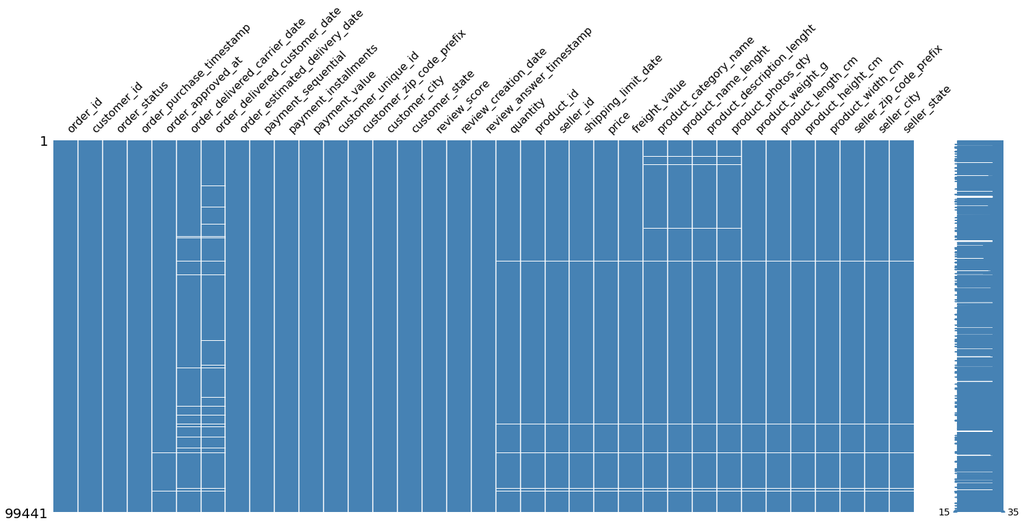

```python
msno.matrix(dataset, color=bleu)
```

```python
missing_values(dataset)
```

```
 Dataframe as 35 columns.
 23 columns containing Nans.
```

|  | Missing values | % on total values |
| --- | --- | --- |
| payment_sequential | 1 | 0.00 |
| payment_installments | 1 | 0.00 |
| payment_value | 1 | 0.00 |
| order_approved_at | 160 | 0.16 |
| seller_zip_code_prefix | 775 | 0.78 |
| seller_city | 775 | 0.78 |
| price | 775 | 0.78 |
| shipping_limit_date | 775 | 0.78 |
| freight_value | 775 | 0.78 |
| product_id | 775 | 0.78 |
| quantity | 775 | 0.78 |
| seller_id | 775 | 0.78 |
| seller_state | 775 | 0.78 |
| product_weight_g | 791 | 0.80 |
| product_length_cm | 791 | 0.80 |
| product_height_cm | 791 | 0.80 |
| product_width_cm | 791 | 0.80 |
| order_delivered_carrier_date | 1783 | 1.79 |
| product_category_name | 2191 | 2.20 |
| product_name_lenght | 2191 | 2.20 |
| product_description_lenght | 2191 | 2.20 |
| product_photos_qty | 2191 | 2.20 |
| order_delivered_customer_date | 2965 | 2.98 |

# EDA

## Types de variables

```python
# Data types of the various columns
dataset.info()
```

```
<class 'pandas.core.frame.DataFrame'>
Int64Index: 99441 entries, 0 to 99440
Data columns (total 35 columns):
 #   Column                         Non-Null Count  Dtype
---  ------                         --------------  -----
 0   order_id                       99441 non-null  object
 1   customer_id                    99441 non-null  object
 2   order_status                   99441 non-null  object
 3   order_purchase_timestamp       99441 non-null  object
 4   order_approved_at              99281 non-null  object
 5   order_delivered_carrier_date   97658 non-null  object
 6   order_delivered_customer_date  96476 non-null  object
 7   order_estimated_delivery_date  99441 non-null  object
 8   payment_sequential             99440 non-null  float64
 9   payment_installments           99440 non-null  float64
```

[output cut: 27 more lines]

## Changement du typage des colonnes contenant des dates

```python
# Change type of date columns
date_columns = ['order_purchase_timestamp',
                'order_approved_at',
                'order_delivered_carrier_date',
                'order_delivered_customer_date',
                'order_estimated_delivery_date',
                'review_creation_date',
                'review_answer_timestamp',
                'shipping_limit_date'
                ]
for col in date_columns:
    dataset[col] = dataset[col].astype('datetime64[ns]')
```

## Delta times

```python
# create delta times starting from order_purchase_timestamp
for col in date_columns[1:]:
    dataset[col]=(dataset[col]-dataset.order_purchase_timestamp)
    dataset[col]=dataset[col].apply(lambda x : x.days)
```

```python
# Create a Var holding rapidity of real vs estimated days for delivery
dataset['quick_delivery']=dataset.order_estimated_delivery_date-dataset.order_delivered_customer_date
```

## Création de la variable cubic_weight

- les frais de port sont partagés entre le client et Olist en fonction d'une grille tenant compte du poid cubique ou du poid produit

```python
# Create volume feature
dataset['product_cubic_weight']=dataset['product_length_cm']*dataset['product_height_cm']*dataset['product_width_cm']/6000
dataset= dataset.drop(['product_length_cm','product_height_cm','product_width_cm'],axis=1)
```

## Création de la variable pourcentage des frais de port par rapport au prix de la commande

```python
# Create ratio betwen total and  freight_value
dataset['freight_price']=dataset['freight_value']/dataset['price']
```

## Suppression des descriptions produits

```python
# Dropping useless and incomplete variables
dataset.drop(['product_name_lenght','product_description_lenght','product_photos_qty'],axis=1,inplace=True)
```

## Suppression des nan

supression des commandes pour lesquelles il manque encore des informations

```python
dataset.dropna(inplace=True)
dataset.shape
```

```
(95101, 32)
```

## Distributions des var numériques

```python
# Summary statistic on numerical features
dataset.describe()
```

|  | order_approved_at | order_delivered_carrier_date | order_delivered_customer_date | order_estimated_delivery_date | payment_sequential | payment_installments | payment_value | customer_zip_code_prefix | review_score | review_creation_date | review_answer_timestamp | quantity | shipping_limit_date | price | freight_value | product_weight_g | seller_zip_code_prefix | quick_delivery | product_cubic_weight | freight_price |
| --- | --- | --- | --- | --- | --- | --- | --- | --- | --- | --- | --- | --- | --- | --- | --- | --- | --- | --- | --- | --- |
| count | 95101.000000 | 95101.000000 | 95101.000000 | 95101.000000 | 95101.000000 | 95101.000000 | 95101.000000 | 95101.000000 | 95101.000000 | 95101.000000 | 95101.000000 | 95101.000000 | 95101.000000 | 95101.000000 | 95101.000000 | 95101.000000 | 95101.000000 | 95101.000000 | 95101.000000 | 95101.000000 |
| mean | 0.264603 | 2.730318 | 12.090451 | 23.376968 | 1.044931 | 2.932630 | 160.042297 | 35185.810601 | 4.146360 | 11.936583 | 14.989874 | 1.142343 | 6.399333 | 125.375535 | 20.196607 | 2103.802704 | 24712.746564 | 11.286516 | 2.533963 | 0.309450 |
| std | 0.730840 | 3.587375 | 9.547406 | 8.772994 | 0.368517 | 2.717435 | 218.723793 | 29827.850708 | 1.293036 | 7.389667 | 12.331832 | 0.539035 | 4.649609 | 189.797256 | 15.836306 | 3757.121138 | 27780.512969 | 10.193506 | 3.886655 | 0.314700 |
| min | 0.000000 | -172.000000 | 0.000000 | 2.000000 | 1.000000 | 0.000000 | 9.590000 | 1003.000000 | 1.000000 | -78.000000 | -33.000000 | 1.000000 | 2.000000 | 0.850000 | 0.000000 | 0.000000 | 1001.000000 | -189.000000 | 0.028000 | 0.000000 |
| 25% | 0.000000 | 1.000000 | 6.000000 | 18.000000 | 1.000000 | 1.000000 | 62.000000 | 11370.000000 | 4.000000 | 7.000000 | 9.000000 | 1.000000 | 5.000000 | 41.800000 | 13.330000 | 300.000000 | 6429.000000 | 7.000000 | 0.469333 | 0.131957 |
| 50% | 0.000000 | 2.000000 | 10.000000 | 23.000000 | 1.000000 | 2.000000 | 105.220000 | 24435.000000 | 5.000000 | 10.000000 | 13.000000 | 1.000000 | 6.000000 | 79.000000 | 16.390000 | 700.000000 | 13660.000000 | 12.000000 | 1.073333 | 0.224374 |
| 75% | 0.000000 | 4.000000 | 15.000000 | 28.000000 | 1.000000 | 4.000000 | 176.880000 | 59025.000000 | 5.000000 | 16.000000 | 19.000000 | 1.000000 | 7.000000 | 139.900000 | 21.260000 | 1813.000000 | 29156.000000 | 16.000000 | 3.062500 | 0.382278 |
| max | 30.000000 | 107.000000 | 209.000000 | 155.000000 | 26.000000 | 24.000000 | 13664.080000 | 99980.000000 | 5.000000 | 111.000000 | 528.000000 | 21.000000 | 1052.000000 | 6735.000000 | 409.680000 | 40425.000000 | 99730.000000 | 146.000000 | 49.368000 | 21.447059 |

## Nettoyage des données

Suite à la l'expression de toutes les dates relativement à order_purchase_timestamp supression des commandes pour lesquelles:

- la remise au transporteur, le dépôt de l'avis client et la réponse du vendeur sont antérieurs à la date de la commande

```python
print(' Orders before {}'.format(dataset.shape[0]))
dataset = dataset.drop( dataset[(dataset['order_delivered_carrier_date'] <0.0)].index)
dataset = dataset.drop( dataset[(dataset['review_creation_date'] <0.0)].index)
dataset = dataset.drop( dataset[(dataset['review_answer_timestamp'] <0.0)].index)

print(' Orders after {}'.format(dataset.shape[0]))
```

```
 Orders before 95101
 Orders after 94931
```

## Dataprep report

```python
import warnings

with warnings.catch_warnings():
    warnings.simplefilter("ignore")
    report=eda.plot(dataset)
report
```

Stats and Insights

Dataset Statistics

Number of Variables

32

Number of Rows

94931

Missing Cells

0

Missing Cells (%)

0.0%

Duplicate Rows

0

Duplicate Rows (%)

0.0%

Total Size in Memory

91.4 MB

Average Row Size in Memory

1009.3 B

Variable Types

- Categorical: 11

- DateTime: 1

- Numerical: 20

Dataset Insights

| order_delivered_customer_date and review_creation_date have similar distributions | Similar Distribution |
| --- | --- |
| order_approved_at is skewed | Skewed |
| order_delivered_carrier_date is skewed | Skewed |
| order_delivered_customer_date is skewed | Skewed |
| order_estimated_delivery_date is skewed | Skewed |
| payment_sequential is skewed | Skewed |
| payment_installments is skewed | Skewed |
| payment_value is skewed | Skewed |
| review_score is skewed | Skewed |
| review_creation_date is skewed | Skewed |

Dataset Insights

| review_answer_timestamp is skewed | Skewed |
| --- | --- |
| quantity is skewed | Skewed |
| shipping_limit_date is skewed | Skewed |
| price is skewed | Skewed |
| freight_value is skewed | Skewed |
| product_weight_g is skewed | Skewed |
| seller_zip_code_prefix is skewed | Skewed |
| quick_delivery is skewed | Skewed |
| product_cubic_weight is skewed | Skewed |
| freight_price is skewed | Skewed |

Dataset Insights

| order_id has a high cardinality: 94931 distinct values | High Cardinality |
| --- | --- |
| customer_id has a high cardinality: 94931 distinct values | High Cardinality |
| customer_unique_id has a high cardinality: 91894 distinct values | High Cardinality |
| customer_city has a high cardinality: 4068 distinct values | High Cardinality |
| product_id has a high cardinality: 30548 distinct values | High Cardinality |
| seller_id has a high cardinality: 2899 distinct values | High Cardinality |
| product_category_name has a high cardinality: 73 distinct values | High Cardinality |
| seller_city has a high cardinality: 588 distinct values | High Cardinality |
| order_id has constant length 32 | Constant Length |
| customer_id has constant length 32 | Constant Length |

Dataset Insights

| customer_unique_id has constant length 32 | Constant Length |
| --- | --- |
| customer_state has constant length 2 | Constant Length |
| product_id has constant length 32 | Constant Length |
| seller_id has constant length 32 | Constant Length |
| seller_state has constant length 2 | Constant Length |
| order_id has all distinct values | Unique |
| customer_id has all distinct values | Unique |
| quick_delivery has 7194 (7.58%) negatives | Negatives |
| order_approved_at has 78291 (82.47%) zeros | Zeros |
| order_delivered_carrier_date has 18768 (19.77%) zeros | Zeros |

- 1

- 2

- 3

- 4

order_id

Column Insights order_id has a high cardinality: 94931 distinct values order_id has constant length 32 order_id has all distinct values

[interactive chart not shown]

customer_id

Column Insights customer_id has a high cardinality: 94931 distinct values customer_id has constant length 32 customer_id has all distinct values

[interactive chart not shown]

order_status

[interactive chart not shown]

order_purchase_timestamp

[interactive chart not shown]

order_approved_at

Column Insights order_approved_at is skewed order_approved_at has 78291 (82.47%) zeros

[interactive chart not shown]

order_delivered_carrier_date

Column Insights order_delivered_carrier_date is skewed order_delivered_carrier_date has 18768 (19.77%) zeros

[interactive chart not shown]

order_delivered_customer_date

Column Insights order_delivered_customer_date is skewed

[interactive chart not shown]

order_estimated_delivery_date

Column Insights order_estimated_delivery_date is skewed

[interactive chart not shown]

payment_sequential

Column Insights payment_sequential is skewed

[interactive chart not shown]

payment_installments

Column Insights payment_installments is skewed

[interactive chart not shown]

payment_value

Column Insights payment_value is skewed

[interactive chart not shown]

customer_unique_id

Column Insights customer_unique_id has a high cardinality: 91894 distinct values customer_unique_id has constant length 32

[interactive chart not shown]

customer_zip_code_prefix

[interactive chart not shown]

customer_city

Column Insights customer_city has a high cardinality: 4068 distinct values

[interactive chart not shown]

customer_state

Column Insights customer_state has constant length 2

[interactive chart not shown]

review_score

Column Insights review_score is skewed

[interactive chart not shown]

review_creation_date

Column Insights review_creation_date is skewed

[interactive chart not shown]

review_answer_timestamp

Column Insights review_answer_timestamp is skewed

[interactive chart not shown]

quantity

Column Insights quantity is skewed

[interactive chart not shown]

product_id

Column Insights product_id has a high cardinality: 30548 distinct values product_id has constant length 32

[interactive chart not shown]

seller_id

Column Insights seller_id has a high cardinality: 2899 distinct values seller_id has constant length 32

[interactive chart not shown]

shipping_limit_date

Column Insights shipping_limit_date is skewed

[interactive chart not shown]

price

Column Insights price is skewed

[interactive chart not shown]

freight_value

Column Insights freight_value is skewed

[interactive chart not shown]

product_category_name

Column Insights product_category_name has a high cardinality: 73 distinct values

[interactive chart not shown]

product_weight_g

Column Insights product_weight_g is skewed

[interactive chart not shown]

seller_zip_code_prefix

Column Insights seller_zip_code_prefix is skewed

[interactive chart not shown]

seller_city

Column Insights seller_city has a high cardinality: 588 distinct values

[interactive chart not shown]

seller_state

Column Insights seller_state has constant length 2

[interactive chart not shown]

quick_delivery

Column Insights quick_delivery is skewed quick_delivery has 7194 (7.58%) negatives

[interactive chart not shown]

product_cubic_weight

Column Insights product_cubic_weight is skewed

[interactive chart not shown]

freight_price

Column Insights freight_price is skewed

[interactive chart not shown]

## On ne prend en compte que les commandes déja livrées

```python
dataset=dataset[(dataset.order_status == 'delivered')]
dataset.shape
```

```
(94925, 32)
```

```python
dataset.to_pickle('Base_client_agregee_nettoyée.pkl')
dataset.to_csv('Base_client_agregee_nettoyée.csv')
```

```python
# Data types of columns
dataset.info()
```

```
<class 'pandas.core.frame.DataFrame'>
Int64Index: 94925 entries, 0 to 99440
Data columns (total 32 columns):
 #   Column                         Non-Null Count  Dtype
---  ------                         --------------  -----
 0   order_id                       94925 non-null  object
 1   customer_id                    94925 non-null  object
 2   order_status                   94925 non-null  object
 3   order_purchase_timestamp       94925 non-null  datetime64[ns]
 4   order_approved_at              94925 non-null  float64
 5   order_delivered_carrier_date   94925 non-null  float64
 6   order_delivered_customer_date  94925 non-null  float64
 7   order_estimated_delivery_date  94925 non-null  int64
 8   payment_sequential             94925 non-null  float64
 9   payment_installments           94925 non-null  float64
```

[output cut: 24 more lines]

```python
import IPython
print(' Executé en : ', datetime.timedelta(seconds=(time.time() - start_time)))
```

```
 Executé en :  0:00:32.629024
```